# Exploratory Data Analysis (EDA) of top_100_clubs

## General Description

### Objective:

The objective of this exploratory data analysis is to understand the structure and content of the `top_100_clubs` dataset. Through visualizations and descriptive statistics, we will explore the main features of the data, the relationships between variables, and identify potential missing data and outliers.

### Content:

1. Introduction and Dataset Description
2. Analysis of Missing Data
3. Univariate Distributions of Variables
4. Bivariate and Multivariate Analysis
5. Identification and Treatment of Outliers
6. Data Transformations and Preparation
7. Conclusions and Next Steps

Introduction

Welcome to the Exploratory Data Analysis (EDA) of the Top 100 Clubs dataset. This analysis aims to provide a comprehensive understanding of the dataset, which includes information about the top 100 nightclubs around the world. Through various visualizations and descriptive statistics, we will explore the key features of the dataset, analyze relationships between variables, and identify any potential missing data or outliers.

Dataset Description

The Top 100 Clubs dataset contains the following six features:

- **Rank:** A numerical ranking of each club based on popularity or other criteria.
- **Club Name:** The official name of the nightclub.
- **Location:** The geographical location of the club, specified as "City, Country".
- **Capacity:** The maximum number of attendees the club can accommodate, provided as a string.
- **Website:** The official website URL of the club, if available.
- **Text:** Descriptive text providing additional information about the club’s unique features, history, and offerings.

By analyzing these features, we aim to uncover interesting insights about the top nightclubs worldwide, understand patterns in their locations and capacities, and highlight any unique attributes mentioned in their descriptions.

```python
import pandas as pd
import numpy as np
import seaborn as sns
import matplotlib.pyplot as plt

import pycountry
import pycountry_convert as pc
from wordcloud import WordCloud, STOPWORDS
import plotly.graph_objs as go
import plotly.express as px
import ipywidgets as widgets

from nltk.corpus import stopwords
from nltk.tokenize import word_tokenize
from collections import Counter


import io
from IPython.display import display, clear_output

sns.set_theme(style="whitegrid")
```

```python
df = pd.read_csv('top_100_clubs.csv')
df.head()
```

|  | Rank | Club_Name | location | capacity | Website | text |
| --- | --- | --- | --- | --- | --- | --- |
| 0 | 1 | Hï Ibiza | Ibiza, Spain | 5,692 | hiibiza.com | What makes a great club? Show-stopping line-up... |
| 1 | 2 | Green Valley | Camboriú, Brazil | 10,000 | greenvalleybr.com | Green Valley continues to bounce back better s... |
| 2 | 3 | Echostage | Washington, DC, USA | 3,000 | echostage.com | Based in the capital of the United States, Ech... |
| 3 | 4 | Ushuaïa Ibiza | Ibiza, Spain | 7,700 | theushuaiaexperience.comEven on an island full... | Even on an island full of clubbing mythology, ... |
| 4 | 5 | Bootshaus | Cologne, Germany | 1,800 | NaN | bootshaus.tv Originally a storage and repair f... |

```python
df.isna().sum()
```

```
Rank          0
Club_Name     0
location      0
capacity      0
Website      31
text          0
dtype: int64
```

```python
df.dtypes
```

```
Rank          int64
Club_Name    object
location     object
capacity     object
Website      object
text         object
dtype: object
```

## Data Cleaning and Preparation Process

1. **Function `extraer_dominio(texto)`:**
   - This function extracts a website domain from text and returns the found domain.
2. **Function `clean_country(row)`:**
   - Cleans and adjusts values in the 'country' column based on specific rules, such as filling null values with 'location', adjusting country names like 'USA' and 'Singapore', among others.
3. **Cleaning and Manipulation of 'capacity':**
   - Removal of commas and plus signs in the 'capacity' column.
   - Splitting 'capacity' into 'capacidad_numero' (capacity number) and 'tipo_venue' (venue type).
4. **Website and 'dominio' Handling:**
   - Extraction of website domains from the 'text' column.
   - Specific assignment of a domain for 'Nightclub'.
   - Updating 'capacity' and 'Website' values based on specific conditions.
5. **Column Selection and Rearrangement:**
   - Selection of specific columns for further analysis, including 'Rank', 'Club_Name', 'location', 'capacity', 'Website', and 'text'.
6. **Location and 'country' Splitting:**
   - Splitting the 'location' column into 'location' and 'country'.
   - Cleaning and adjusting country names using the `clean_country` function.
7. **Continent Assignment:**
   - Automatic assignment of continents using country names and the `pycountry` package.
   - Manual assignment of continents for specific locations such as 'Austin' and 'Dubai'.

This data cleaning and preparation process ensures that the `df` DataFrame is ready for detailed exploratory analysis of the top nightclubs.

```python
def extraer_dominio(texto):
    palabras = texto.split()
    for palabra in palabras:
        if '.' in palabra:
            return palabra

    return None

def clean_country(row):
    if pd.isna(row['country']):
        return row['location']
    elif row['country'].endswith('USA'):
        return 'USA'
    elif row['country'] == 'Singapore. Singapore':
        return  'Singapore'
    else:
        return row['country']
```

```python
df['capacity'] = df['capacity'].str.replace(',','')
df['capacity'] = df['capacity'].str.replace('+','')

df[['capacidad_numero', 'tipo_venue']] = df['capacity'].str.split(' ', n=1, expand=True)


df['capacidad_numero'] = pd.to_numeric(df['capacidad_numero'].str.split(' ').str[0], errors='coerce')


df['tipo_venue'] = df['tipo_venue'].str.extract(r'\((.*?)\)')

df['dominio'] = df['text'].apply(extraer_dominio)

df.loc[df['tipo_venue'] == 'Nightclub', 'dominio'] = 'taogroup.com/venues/marquee-las-vegas'
df['capacity'] = np.where(df['Website'].isna(), df['capacidad_numero'] , df['capacity'])
df['capacity'] = np.where(df['capacity'].isna(), df['capacidad_numero'] , df['capacity'])
df['Website'] = np.where(df['Website'].isna(), df['dominio'] , df['Website'])


df['dominio'] = df['Website'].apply(extraer_dominio)
df['Website'] = df['dominio']
df = df[['Rank', 'Club_Name', 'location', 'capacity', 'Website', 'text']]
df['capacity'] = pd.to_numeric(df['capacity'])

df[['location', 'country']] = df['location'].str.split(',', n=1, expand=True)
df['country'] = df.apply(clean_country, axis=1)
```

```python
continent_dict = {
    'AF': 'Africa',
    'AS': 'Asia',
    'EU': 'Europe',
    'NA': 'North America',
    'OC': 'Oceania',
    'SA': 'South America'
}

def get_continent(country_name):
    try:
        country = pycountry.countries.get(name=country_name)
        if not country:
            country = pycountry.countries.search_fuzzy(country_name)[0]
        country_alpha2 = country.alpha_2
        continent_code = pc.country_alpha2_to_continent_code(country_alpha2)
        return continent_dict[continent_code]
    except Exception as e:
        return None


df['continent'] = df['country'].apply(get_continent)

df.loc[df['location'] =='Austin','continent'] = 'North America'
df.loc[df['location'] =='Dubai','continent'] = 'Asia'
```

```python
df.isna().sum()
```

```
Rank         0
Club_Name    0
location     0
capacity     0
Website      0
text         0
country      0
continent    1
dtype: int64
```

```python
df.describe()
```

|  | Rank | capacity |
| --- | --- | --- |
| count | 100.000000 | 100.000000 |
| mean | 50.500000 | 2651.850000 |
| std | 29.011492 | 2949.072322 |
| min | 1.000000 | 300.000000 |
| 25% | 25.750000 | 1000.000000 |
| 50% | 50.500000 | 1927.500000 |
| 75% | 75.250000 | 3000.000000 |
| max | 100.000000 | 20000.000000 |

# Continent Ranking Analysis

In this analysis, we grouped the club data by continent and calculated the average ranking and the total number of clubs per continent. The results are as follows:

```python
rank_continent = df.groupby('continent').agg({'Rank':'mean','Club_Name':'count'}).reset_index()
rank_continent['Rank'] = rank_continent['Rank'].round(2)
rank_continent.rename(columns={'Club_Name':'Total Club'}, inplace=True)
rank_continent.sort_values(by='Rank', ascending=True)
```

|  | continent | Rank | Total Club |
| --- | --- | --- | --- |
| 5 | South America | 44.00 | 9 |
| 1 | Asia | 47.35 | 23 |
| 2 | Europe | 49.86 | 37 |
| 0 | Africa | 51.50 | 8 |
| 3 | North America | 55.10 | 21 |
| 4 | Oceania | 78.00 | 1 |

## Conclusions

1. **South America** has the lowest average rank (44.00), indicating that clubs from this continent generally have better positions in the ranking compared to other continents.
2. **Asia** ranks second with an average rank of 47.35. Despite having a significant number of clubs (23), it maintains a relatively low average rank.
3. **Europe** has the highest number of clubs (37) and an average rank of 49.86. This suggests more intense competition within the continent.
4. **Africa** and **North America** have average ranks of 51.50 and 55.10 respectively, placing them in the middle of the table.
5. **Oceania** has the worst average rank (78.00), but this may be influenced by the fact that there is only one club represented in the analysis.

## Additional Observations

- **Regional Competitiveness**: The data suggests that South America and Asia have clubs that are, on average, better positioned in the ranking, indicating higher competitiveness and level of play in these continents.
- **Club Diversity**: Europe, with the highest number of clubs, shows greater diversity and depth in representation, although its average rank is not the highest.
- **Influence of Number of Clubs**: Continents with fewer clubs (such as Oceania and Africa) may have their average ranks more easily influenced by the performance of a few clubs.

## Combined Visualization of Club Capacities and Ranking

### Histogram of Club Capacities

- **Purpose:** Visualize the distribution of capacities among the top clubs.
- **Method:**
  - Utilized seaborn's `histplot` function to create a histogram.
  - Binned the capacities into 10 bins for a clear distribution overview.
- **Visual Elements:**
  - Title: "Distribution of Club Capacities"
  - X-axis: Represents the capacity values.
  - Y-axis: Represents the frequency of clubs in each capacity bin.

### Scatter Plot of Capacity versus Ranking

- **Purpose:** Explore the relationship between club capacity and their ranking.
- **Method:**
  - Employed seaborn's `scatterplot` function to generate a scatter plot.
  - Plotted club capacities against their respective ranks.
- **Visual Elements:**
  - Title: "Relationship Between Capacity and Ranking"
  - X-axis: Shows the club capacities.
  - Y-axis: Displays the ranking of clubs.

### Layout and Presentation

- **Subplots Configuration:**
  - Created a figure with 1 row and 2 columns to display both visualizations side by side.
- **Adjustments:**
  - Used `plt.tight_layout()` to ensure proper spacing between the subplots.
- **Output:**
  - Displayed the combined visualization using `plt.show()`.

This approach allows for a comprehensive analysis of club data, examining both the distribution of capacities and the relationship between capacity and ranking in a single visual display.

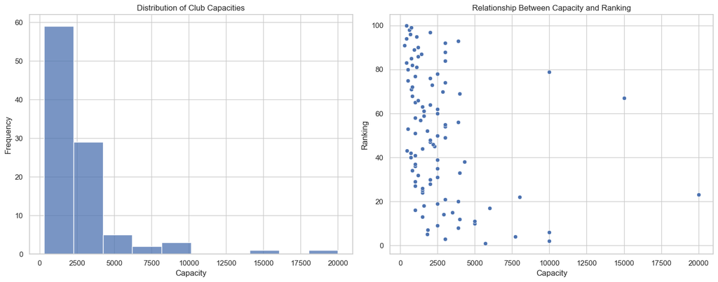

```python
# Crear una figura con subplots
fig, (ax1, ax2) = plt.subplots(1, 2, figsize=(15, 6))

# Histograma de capacidades de los clubes
sns.histplot(df['capacity'], bins=10, ax=ax1)
ax1.set_title('Distribution of Club Capacities')
ax1.set_xlabel('Capacity')
ax1.set_ylabel('Frequency')

# Scatter plot entre capacidad y ranking
sns.scatterplot(x='capacity', y='Rank', data=df, ax=ax2)
ax2.set_title('Relationship Between Capacity and Ranking')
ax2.set_xlabel('Capacity')
ax2.set_ylabel('Ranking')

# Ajustar espaciado entre subplots
plt.tight_layout()

# Mostrar los gráficos
plt.show()
```

```python
# Definir las stopwords adicionales que deseas remover
additional_stopwords = {'will', 's', 'Ltd', 'etc', 'club', '7JQ', 'year'}

# Función para generar un Word Cloud con las stopwords removidas
def generate_wordcloud(text):
    stop_words = set(stopwords.words('english'))
    stop_words.update(additional_stopwords)
    words = word_tokenize(text.lower())
    cleaned_words = [word for word in words if word.isalnum() and word not in stop_words]
    cleaned_text = ' '.join(cleaned_words)
    wordcloud = WordCloud(width=800, height=400, background_color='white').generate(cleaned_text)
    return wordcloud

# Inicializar un Plotly figure globalmente
fig = go.Figure()

# Función para mostrar un Word Cloud interactivo en Plotly por continente
def create_wordclouds_by_continent(df):
    continents = df['continent'].unique()

    def plot_wordcloud(continent):
        global fig  # Declarar fig como global

        # Clear existing data and traces in the figure
        fig.data = []

        # Filter top clubs for the selected continent
        continent_df = df[df['continent'] == continent]

        # Combine all text into one string for the word cloud
        combined_text = ' '.join(continent_df['text'].dropna())

        # Generar word cloud con stopwords removidas
        wordcloud = generate_wordcloud(combined_text)

        # Update the Plotly figure with the new word cloud
        fig.add_layout_image(
            source=wordcloud.to_image(),
            x=0, y=1,  # Posición de la imagen
            xanchor='left', yanchor='top',
            sizex=1, sizey=1,  # Escalar la imagen para que quepa
            sizing='contain'
        )

        # Actualizar las propiedades del layout
        fig.update_layout(
            title=f'Clubs Word Cloud - {continent}',
            xaxis=dict(visible=False),
            yaxis=dict(visible=False),
            width=800,
            height=400
        )

        # Limpiar cualquier salida previa de Plotly
        clear_output(wait=True)

        # Mostrar el gráfico actualizado de Plotly
        display(fig)

    # Crear un widget dropdown para seleccionar continente
    dropdown_continent = widgets.Dropdown(options=continents, description='Continent:')

    # Llamar de forma interactiva a la función plot_wordcloud basado en la selección del continente
    widgets.interact(plot_wordcloud, continent=dropdown_continent)



def create_wordcloud_top_10(df):
    top_10 = df.nsmallest(10, 'Rank')

    # Combine all text into one string for the word cloud
    combined_text = ' '.join(top_10['text'].dropna())

    # Create the word cloud with stopwords
    stopwords = set(STOPWORDS)
    stopwords.update(additional_stopwords)
    wordcloud = WordCloud(width=800, height=400, background_color='white', stopwords=stopwords).generate(combined_text)

    # Display the word cloud
    plt.figure(figsize=(10, 5))
    plt.imshow(wordcloud, interpolation='bilinear')
    plt.title('Top 10 Clubs Word Cloud')
    plt.axis('off')
    plt.show()


def process_text(text):
    stop_words = set(stopwords.words('english'))  # Puedes ajustar el idioma según tu caso

    # Tokenización y limpieza
    words = word_tokenize(text.lower())  # Tokenización y minúsculas
    cleaned_words = [word for word in words if word.isalnum() and word not in stop_words]  # Eliminar stopwords y no alfanuméricos

    return cleaned_words

# Función para obtener las palabras más usadas por continente
def get_top_words_by_continent(df, continent, top_n=5):
    # Filtrar los datos por continente
    continent_df = df[df['continent'] == continent]

    # Combinar todo el texto para el continente seleccionado
    combined_text = ' '.join(continent_df['text'].dropna())

    # Procesar el texto y obtener las palabras limpias
    cleaned_words = process_text(combined_text)

    # Conteo de frecuencia de palabras
    word_counts = Counter(cleaned_words)

    # Obtener las palabras más comunes (por ejemplo, las top_n más comunes)
    top_words = word_counts.most_common(top_n)

    return top_words

# Ejemplo de uso
create_wordclouds_by_continent(df)
```

```
interactive(children=(Dropdown(description='Continent:', options=('Europe', 'South America', 'North America', …
```

```python
df
```

|  | Rank | Club_Name | location | capacity | Website | text | country | continent |
| --- | --- | --- | --- | --- | --- | --- | --- | --- |
| 0 | 1 | Hï Ibiza | Ibiza | 5692 | hiibiza.com | What makes a great club? Show-stopping line-up... | Spain | Europe |
| 1 | 2 | Green Valley | Camboriú | 10000 | greenvalleybr.com | Green Valley continues to bounce back better s... | Brazil | South America |
| 2 | 3 | Echostage | Washington | 3000 | echostage.com | Based in the capital of the United States, Ech... | USA | North America |
| 3 | 4 | Ushuaïa Ibiza | Ibiza | 7700 | theushuaiaexperience.comEven | Even on an island full of clubbing mythology, ... | Spain | Europe |
| 4 | 5 | Bootshaus | Cologne | 1800 | bootshaus.tv | bootshaus.tv Originally a storage and repair f... | Germany | Europe |
| ... | ... | ... | ... | ... | ... | ... | ... | ... |
| 95 | 96 | New City Gas | Montréal | 670 | newcitygas.com | Industrial warehouse venue, New City Gas, used... | Canada | North America |
| 96 | 97 | Spazio 900 | Rome | 2000 | spazionovecento.it | spazionovecento.it Situated in EUR, the busine... | Italy | Europe |
| 97 | 98 | And Club | Johannesburg | 600 | andclub.co.za | andclub.co.za And Club has humble beginnings —... | South Africa | Africa |
| 98 | 99 | Octava | Bogotá | 750 | octavaclub.com | Located in Colombia’s capital within the livel... | Colombia | South America |
| 99 | 100 | La Feria | Santiago | 400 | clublaferia.com | If you've heard of one club in Chile it will u... | Chile | South America |

100 rows × 8 columns

```python
top_words_list = []

continents = df['continent'].unique()
# Iterar sobre cada continente y obtener las palabras más usadas
for continent in continents:
    top_words = get_top_words_by_continent(df, continent, top_n=5)
    top_words_dict = {f"{i+1}_word": word for i, (word, count) in enumerate(top_words)}
    top_words_dict['Continent'] = continent
    top_words_list.append(top_words_dict)

# Convertir la lista de diccionarios en un DataFrame
top_words_df = pd.DataFrame(top_words_list)

top_words_df = top_words_df[~top_words_df['Continent'].isna()][['Continent','1_word', '2_word', '3_word', '4_word', '5_word']]
top_words_df
```

|  | Continent | 1_word | 2_word | 3_word | 4_word | 5_word |
| --- | --- | --- | --- | --- | --- | --- |
| 0 | Europe | club | street | thrust | publishing | ltd |
| 1 | South America | club | music | green | valley | year |
| 2 | North America | club | year | 3 | united | thrust |
| 3 | Africa | london | street | thrust | publishing | ltd |
| 4 | Asia | club | street | thrust | publishing | ltd |
| 6 | Oceania | home | overlooking | sydney | grand | darling |

### Conclusions from the Analysis of Most Used Words by Continent

1. **Europe**: The most frequent words include "club," "street," "thrust," "publishing," and "ltd," indicating a high presence of terms related to clubs, streets, and publishing.
2. **South America**: Standout terms like "club," "music," "green," "valley," and "year" suggest a diversity of interests from music to nature.
3. **North America**: "Club," "year," "3," "united," and "thrust" are common, reflecting a mix of generic and specific terms.
4. **Africa**: Among the top words are "london," "street," "thrust," "publishing," and "ltd," indicating a significant presence of terms related to London and publications.
5. **Asia**: Similar to other continents, "club," "street," "thrust," "publishing," and "ltd" are observed, suggesting common themes across various Asian regions.
6. **Oceania**: Words such as "home," "overlooking," "sydney," "grand," and "darling" are prominent, indicating a focus on local and specific geographic themes.

This analysis reveals interesting patterns in the usage of key words that may reflect cultural, geographical, and economic trends in each continent.

```python
def averageplot(column, bycolumn , location_stats):
    plt.figure(figsize=(12, 6))
    sns.barplot(x=column, y=bycolumn, data=location_stats)
    plt.title(f'Average {bycolumn} by {column}')
    plt.xlabel(column)
    plt.ylabel(f'Average {bycolumn}')
    plt.xticks(rotation=45)
    plt.tight_layout()
    plt.show()



def relationship(column):
    location_stats = df.groupby(column).agg({
    'capacity': 'mean',
    'Rank': 'mean',
    'Club_Name': 'count'
}).reset_index()

    location_stats = location_stats[location_stats['Club_Name'] > 1]

    averageplot(column, 'capacity', location_stats)
    averageplot(column, 'Rank', location_stats)
```

more capacity best rank?

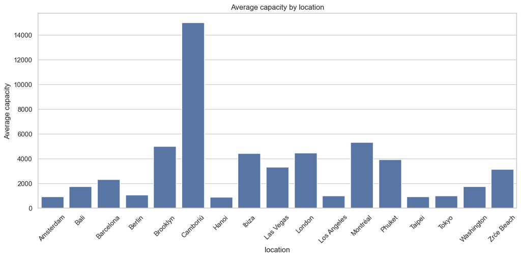

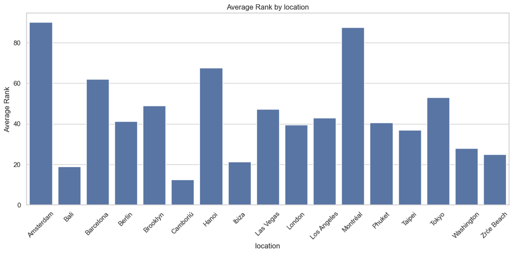

```python
relationship('location')
```

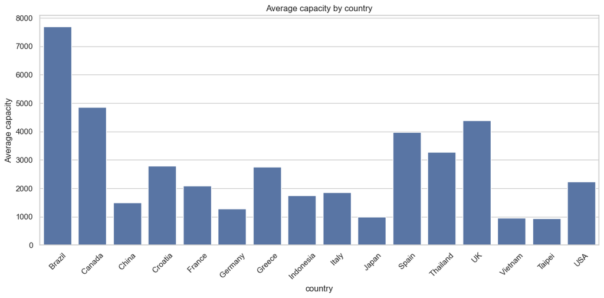

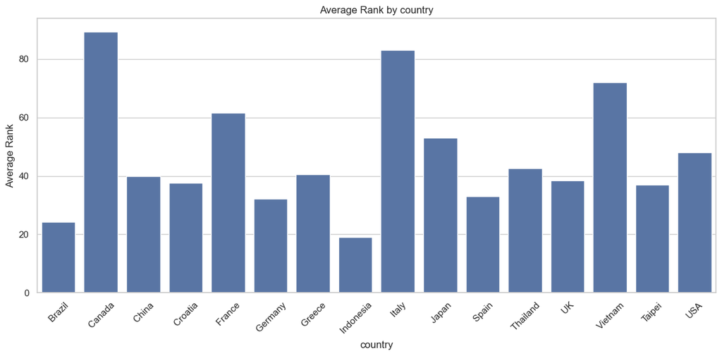

```python
relationship('country')
```

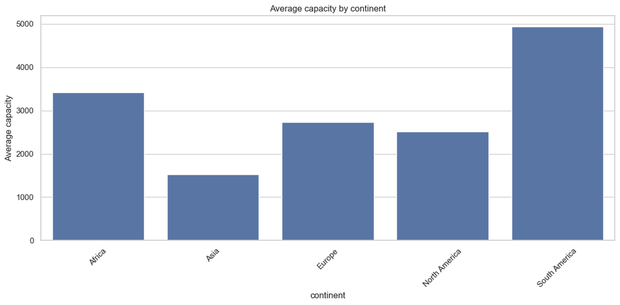

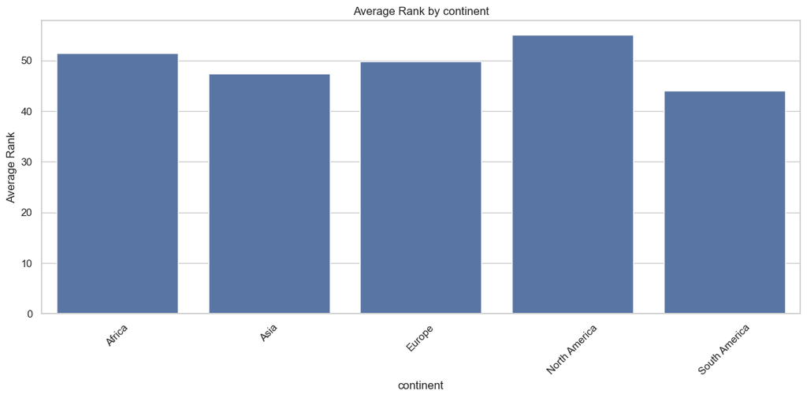

```python
relationship('continent')
```

```python
correlation_matrix = df[['capacity', 'Rank']].corr()
correlation_matrix
```

|  | capacity | Rank |
| --- | --- | --- |
| capacity | 1.000000 | -0.315137 |
| Rank | -0.315137 | 1.000000 |

With this knowledge, I proceeded to examine the word cloud for the top 10 ranked clubs

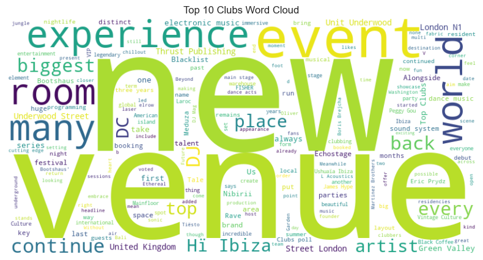

```python
create_wordcloud_top_10(df)
```

```python
additional_stopwords = {'will', 's', 'Ltd', 'etc', 'club', '7JQ', 'year','&','Las','Los'}
```

```python
def get_top_words(df, rank_range=(1, 10), top_n=5):
    # Obtener las stopwords en el idioma adecuado (ej. inglés)
    stop_words = set(stopwords.words('english'))
    stop_words.update(additional_stopwords)
    # Filtrar el DataFrame para obtener los clubes dentro del rango de rango de rango
    filtered_df = df[(df['Rank'] >= rank_range[0]) & (df['Rank'] <= rank_range[1])]

    # Obtener todas las palabras de la columna 'Club_Name' de los clubes filtrados
    all_words = ' '.join(filtered_df['Club_Name']).split()

    # Filtrar las stopwords
    filtered_words = [word for word in all_words if word.lower() not in stop_words]

    # Contar las palabras más comunes
    most_common_words = Counter(filtered_words).most_common(top_n)

    return most_common_words

# Ejemplo de uso
# Obtener las palabras más usadas en los clubes con rango de 1 a 10
top_words = get_top_words(df, rank_range=(1, 10), top_n=5)

# Crear un diccionario con las palabras más usadas
top_words_dict = {f"{i+1}_word": word for i, (word, count) in enumerate(top_words)}
top_words_dict['Continent'] = 'Top 10 Clubs (Rank 1-10)'

# Convertir el diccionario en un DataFrame
top_words_df = pd.DataFrame([top_words_dict])

# Reordenar las columnas y mostrar el DataFrame
top_words_df = top_words_df[['Continent', '1_word', '2_word', '3_word', '4_word', '5_word']]
top_words_df
```

|  | Continent | 1_word | 2_word | 3_word | 4_word | 5_word |
| --- | --- | --- | --- | --- | --- | --- |
| 0 | Top 10 Clubs (Rank 1-10) | Ibiza | Hï | Green | Valley | Echostage |

```python
def get_top_words(df, column, top_n=5):
    stop_words = set(stopwords.words('english'))
    all_words = ' '.join(df[column]).split()
    filtered_words = [word for word in all_words if word.lower() not in stop_words]
    most_common_words = Counter(filtered_words).most_common(top_n)
    return most_common_words

# Función para realizar análisis y comparación por segmentos de ranking
def analyze_rank_segments(df, rank_segments=[(1, 10), (11, 20), (21, 50)], column='Club_Name', top_n=5):
    results = []

    for segment in rank_segments:
        # Filtrar el DataFrame para el segmento de ranking actual
        filtered_df = df[(df['Rank'] >= segment[0]) & (df['Rank'] <= segment[1])]

        # Obtener las palabras más comunes en la columna especificada
        top_words = get_top_words(filtered_df, column, top_n=top_n)

        # Crear un diccionario con los resultados del segmento actual
        segment_dict = {
            'Segment': f'Rank {segment[0]}-{segment[1]}',
            '1_word': top_words[0][0] if len(top_words) > 0 else '',
            '2_word': top_words[1][0] if len(top_words) > 1 else '',
            '3_word': top_words[2][0] if len(top_words) > 2 else '',
            '4_word': top_words[3][0] if len(top_words) > 3 else '',
            '5_word': top_words[4][0] if len(top_words) > 4 else ''
        }

        results.append(segment_dict)

    # Convertir los resultados en un DataFrame
    results_df = pd.DataFrame(results)

    return results_df
```

```python
rank_segments = [(1, 10), (11, 20), (21, 50),(51,80),(81,100)]  # Por ejemplo, top 10, 11-20, y 21-50

# Realiza el análisis y comparación por segmentos de ranking en la columna 'Club_Name'
segment_analysis_df = analyze_rank_segments(df, rank_segments=rank_segments, column='Club_Name', top_n=5)
segment_analysis_df
```

|  | Segment | 1_word | 2_word | 3_word | 4_word | 5_word |
| --- | --- | --- | --- | --- | --- | --- |
| 0 | Rank 1-10 | Ibiza | Hï | Green | Valley | Echostage |
| 1 | Rank 11-20 | Illuzion | Noa | Beach | Club | Berghain |
| 2 | Rank 21-50 | Club | & | LA | Space | Beach |
| 3 | Rank 51-80 | Club | Grand | Beach | D-Edge | MAD |
| 4 | Rank 81-100 | Club | POCPOC | Garden | Caposile | MUZE |

This nuanced analysis underscores the varying influences of geographical location and club attributes across different ranking segments, providing valuable insights into the factors driving club rankings.

```python
data = {
    'segment': [],
    'location': [],
    'count': []
}

# Segmentación del DataFrame según los rangos especificados
segmentos = [(1, 10), (11, 20), (21, 50), (51, 80), (81, 100)]

# Iterar sobre cada segmento
for segmento in segmentos:
    start, end = segmento
    # Filtrar el DataFrame por el rango actual
    segmento_df = df.iloc[start-1:end]  # Restamos 1 porque el índice en Python comienza desde 0

    # Contar las repeticiones de cada lugar y seleccionar los 5 más repetidos
    top_5_lugares = segmento_df['location'].value_counts().head(5)

    # Agregar los resultados al diccionario de datos
    for posicion, (club_name, repeticiones) in enumerate(top_5_lugares.items(), start=1):
        data['segment'].append(f"{start}-{end}")
        data['location'].append(club_name)
        data['count'].append(repeticiones)

# Crear el DataFrame final
result_df = pd.DataFrame(data)


fig = px.bar(result_df, x='segment', y='count', color='location',
             title='Conteo de lugares por segmento y ubicación'
             )

# Mostrar gráfico interactivo
fig.show()
```

[output not shown]

```python
!jupyter nbconvert --to html base.ipynb
```